# Improving assessment

With Diagnostic Classification Models

W. Jake Thompson, Ph.D.

# Welcome!

## Who am I?

W. Jake Thompson, Ph.D.

- Assistant Director of Psychometrics
  - [ATLAS](https://atlas.ku.edu) | University of Kansas
- Research: Applications of diagnostic psychometric models
  - Lead psychometrician and Co-PI for the [Dynamic Learnings Maps](https://dynamiclearningmaps.org) assessments
  - PI for an [IES-funded](https://ies.ed.gov/funding/grantsearch/details.asp?ID=4546) project to develop software for diagnostic models

[figure not shown]

[@wjakethompson](https://www.gitub.com/wjakethompson)  
[@wjakethompson.com](https://bsky.app/profile/wjakethompson.com)

## Materials

All materials are available on the workshop website:

https://learn.r-dcm.org

## Installation

- Required
  - R (≥ 4.5.0)
  - rstan (≥ 2.32.7)
  - measr (≥ 2.0.1)
- Recommended
  - RStudio (≥ 2026.01.1-403)
  - cmdstanr (≥ 0.9.0)
  - CmdStan (≥ 2.38.0)

## Copy and run

```r
install.packages(c("measr", "tidyverse", "here", "fs", "usethis"))

# Optional
install.packages(
  c("rstan", "StanHeaders", "cmdstanr"),
  repos = c("https://stan-dev.r-universe.dev", getOption("repos"))
)

## check toolchain
cmdstanr::check_cmdstan_toolchain()
cmdstanr::install_cmdstan(cores = 2)
```

For help installing RStan, CmdStanR, or configuring the toolchain, see the prework page (https://learn.r-dcm.org/materials/prework).

# Diagnostic assessments

[figure not shown]

- Traditional assessments and psychometric models measure an overall skill or ability
- Assume a continuous latent trait

[figure not shown]

- The output is a weak ordering due to error in estimates
  - Confident *Taylor Swift* (debut) is the worst
  - Not confident on ordering toward the middle of the distribution

[figure not shown]

- Limited in the types of questions that can be answered.
  - Why is *Taylor Swift* (debut) so low?
  - What aspects do each era demonstrate proficiency or competency of?
  - How much skill is “enough” to be competent?

[figure not shown]

## Diagnostic measurement

- Designed to be multidimensional
- No continuum of student achievement
- Categorical constructs
  - Usually binary (e.g., master/nonmaster, proficient/not proficient)
- Several different names in the literature
  - Diagnostic classification models (DCMs)
  - Cognitive diagnostic models (CDMs)
  - Skills assessment models
  - Latent response models
  - Restricted latent class models

## Diagnostic music assessment

- Rather than measuring overall musical knowledge, we can break music down into set of skills or *attributes*
  - Songwriting
  - Production
  - Vocals

[figure not shown]

- Attributes are categorical, often dichotomous (e.g., proficient vs. non-proficient)

## Diagnostic classification models

- DCMs place individuals into groups according to proficiency of multiple attributes
- Students are probabilistically placed into classes
  - Classes are represented by skill profiles
- Feedback on specific skills as defined by the cognitive theory and test design
- No scale, no overall “ability”

songwriting

production

vocals

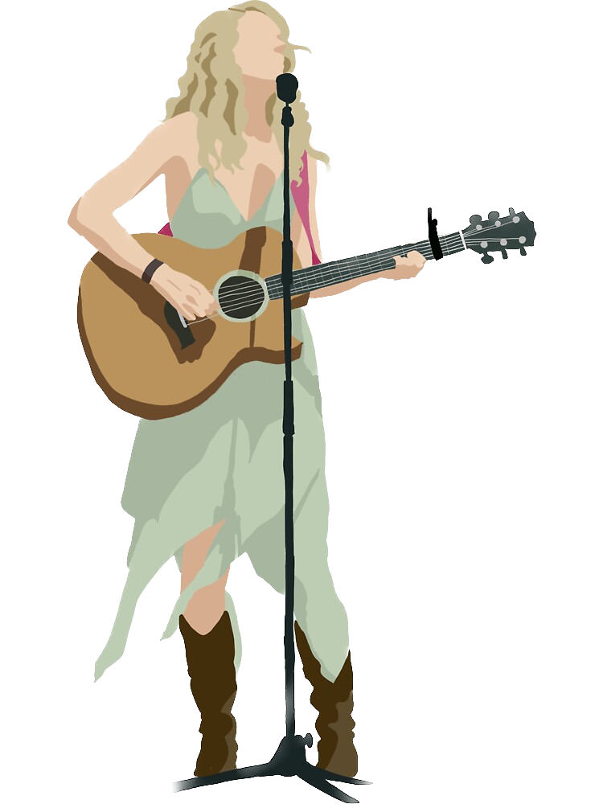

[figure not shown]

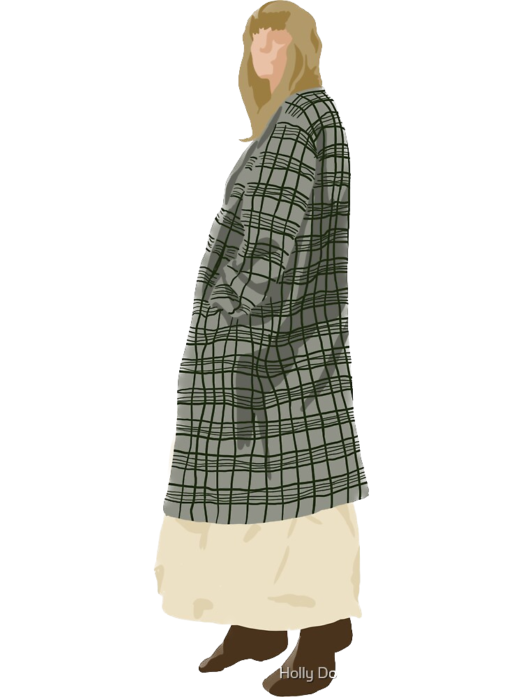

## Benefits of DCMs

- Fine-grained, multidimensional results. Answer more questions:
  - Why is *Taylor Swift* (debut) so low?
    - Subpar songwriting, production, and vocals
  - What aspects are albums competent/proficient in?
    - DCMs provide classifications directly
- High reliability with fewer items
  - Less information need to classify than to place precisely along a scale

songwriting

production

vocals

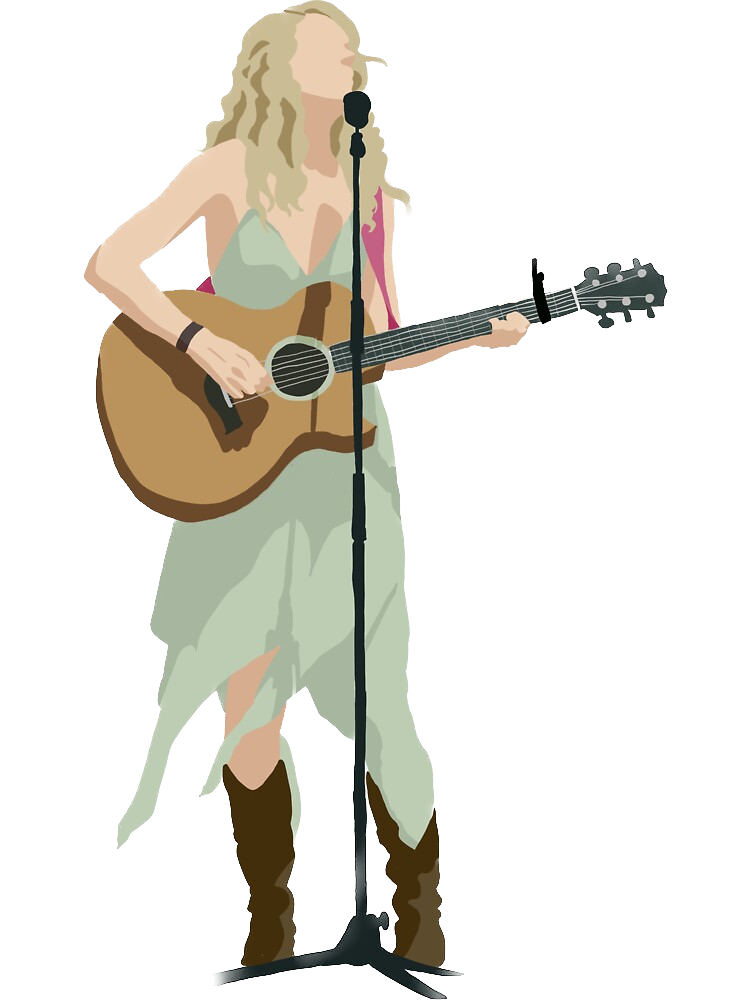

[figure not shown]

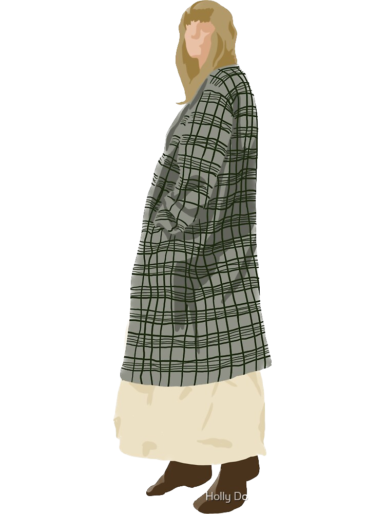

## Fine-grained feedback

- Distinguish between respondents who may have similar scale scores

songwriting

production

vocals

[figure not shown]

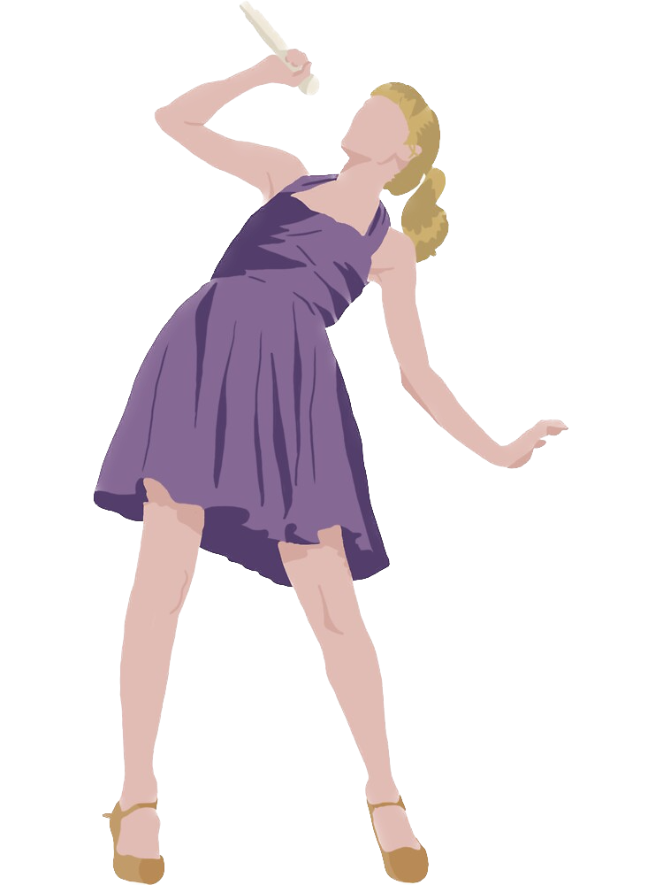

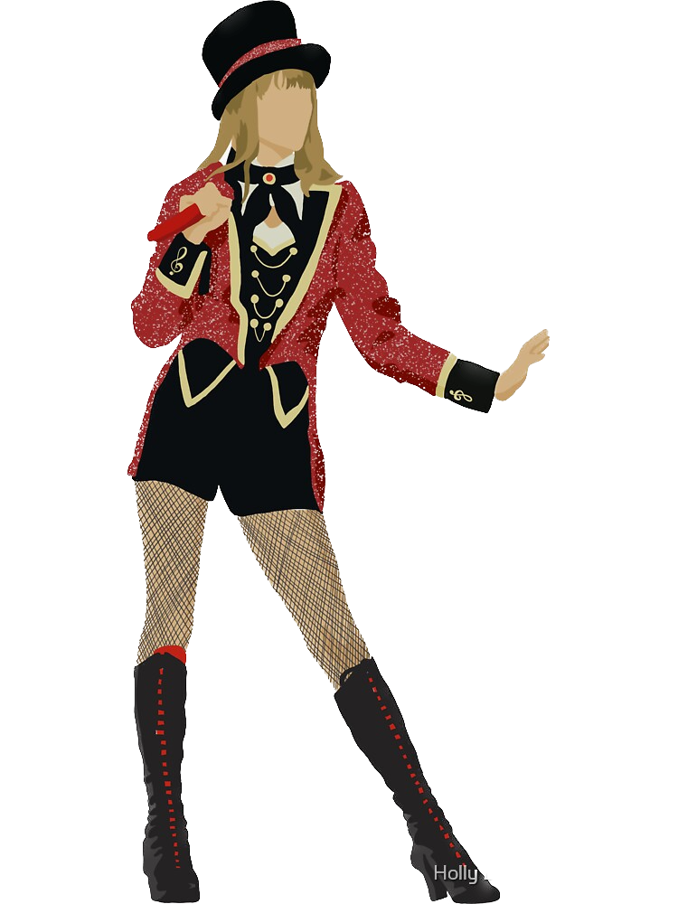

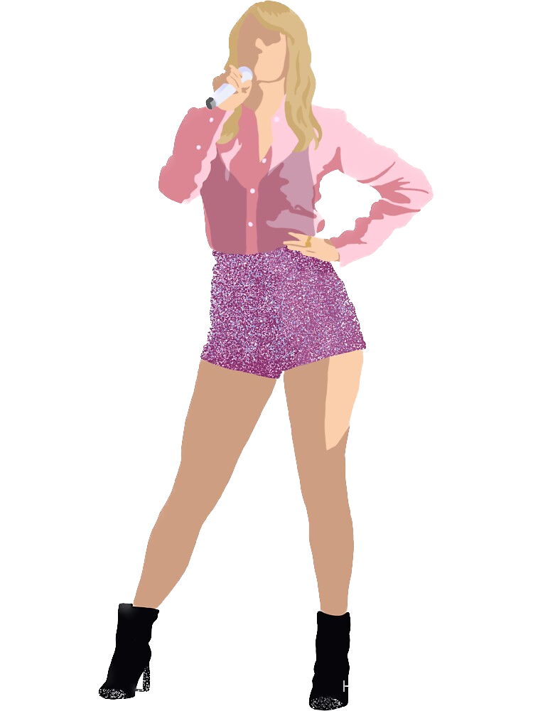

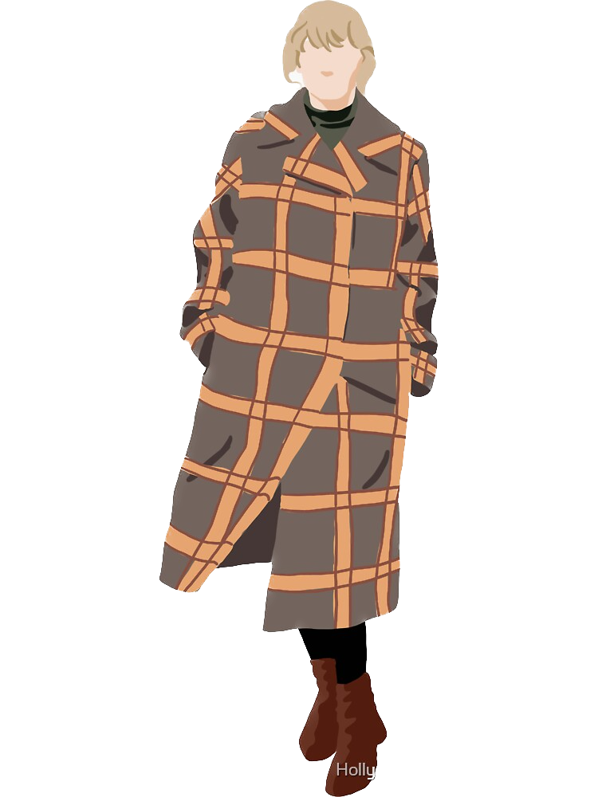

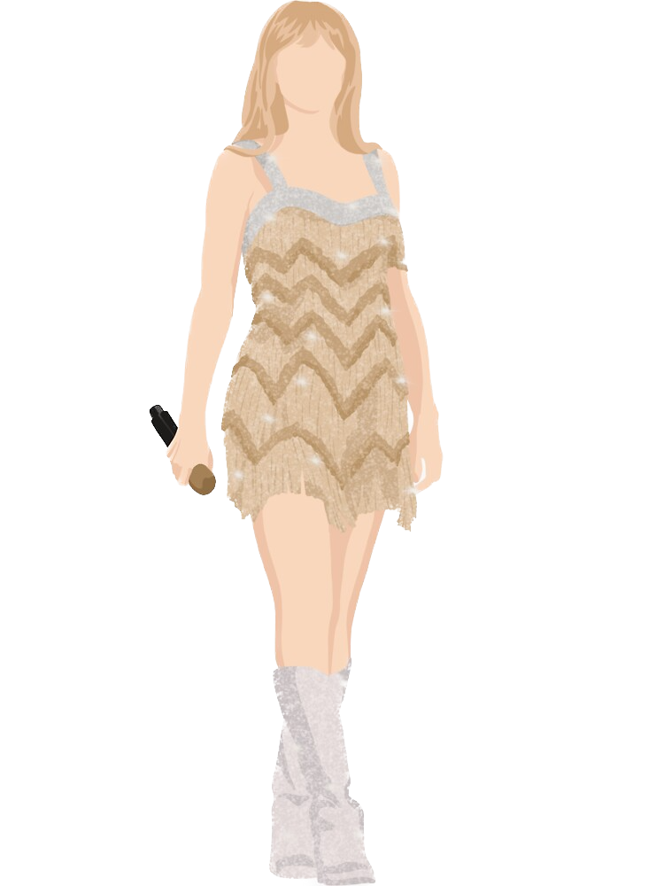

[figure not shown]

[figure not shown]

## When are DCMs appropriate?

Success depends on:

1. Domain definitions
   - What are the attributes we’re trying to measure?
   - Are the attributes measurable (e.g., with assessment items)?
2. Alignment of purpose between assessment and model
   - Is classification the purpose?

## Example applications

- **Educational measurement:** The competencies that student is or is not proficient in
  - Latent knowledge, skills, or understandings
  - Used for tailored instruction and remediation
- **Psychiatric assessment:** The DSM criteria that an individual meets
  - Broader diagnosis of a disorder

## When are DCMs not appropriate?

- When the goal is to place individuals on a scale
- DCMs do not distinguish within classes

songwriting

production

vocals

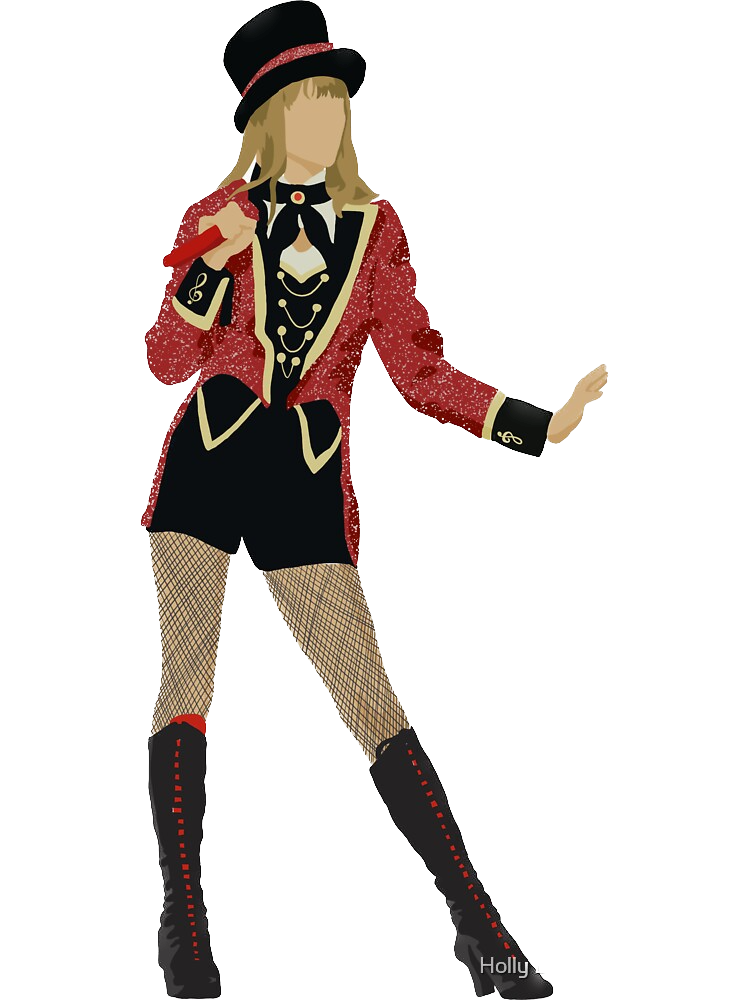

[figure not shown]

[figure not shown]

# Using diagnostic models

[figure not shown]

## What is measr?

- R package that automates the creation of Stan scripts for DCMs
- Wraps rstan or cmdstanr to estimate the models
- Provides additional functions to automate the evaluation of DCMs
  - Model fit
  - Classification accuracy and consistency

## Data for examples

- Examination for the certificate of proficiency in English (ECPE; [Templin & Hoffman, 2013](https://doi.org/10.1111/emip.12010))
  - 28 items measuring 3 total attributes
  - 2,922 respondents
- 3 attributes
  - Morphosyntactic rules
  - Cohesive rules
  - Lexical rules

## ECPE data

```r
library(dcmdata)

ecpe_data
```

```
#> # A tibble: 2,922 × 29
#>    resp_id    E1    E2    E3    E4    E5    E6    E7    E8    E9   E10   E11
#>      <int> <int> <int> <int> <int> <int> <int> <int> <int> <int> <int> <int>
#>  1       1     1     1     1     0     1     1     1     1     1     1     1
#>  2       2     1     1     1     1     1     1     1     1     1     1     1
#>  3       3     1     1     1     1     1     1     0     1     1     1     1
#>  4       4     1     1     1     1     1     1     1     1     1     1     1
#>  5       5     1     1     1     1     1     1     1     1     1     1     1
#>  6       6     1     1     1     1     1     1     1     1     1     1     1
#>  7       7     1     1     1     1     1     1     1     1     1     1     1
#>  8       8     0     1     1     1     1     1     0     1     1     1     0
#>  9       9     1     1     1     1     1     1     1     1     1     1     1
#> 10      10     1     1     1     1     0     0     1     1     1     1     1
#> # ℹ 2,912 more rows
#> # ℹ 17 more variables: E12 <int>, E13 <int>, E14 <int>, E15 <int>, E16 <int>,
#> #   E17 <int>, E18 <int>, E19 <int>, E20 <int>, E21 <int>, E22 <int>,
#> #   E23 <int>, E24 <int>, E25 <int>, E26 <int>, E27 <int>, E28 <int>
```

## ECPE Q-matrix

```r
ecpe_qmatrix
```

```
#> # A tibble: 28 × 4
#>    item_id morphosyntactic cohesive lexical
#>    <chr>             <int>    <int>   <int>
#>  1 E1                    1        1       0
#>  2 E2                    0        1       0
#>  3 E3                    1        0       1
#>  4 E4                    0        0       1
#>  5 E5                    0        0       1
#>  6 E6                    0        0       1
#>  7 E7                    1        0       1
#>  8 E8                    0        1       0
#>  9 E9                    0        0       1
#> 10 E10                   1        0       0
#> # ℹ 18 more rows
```

## Data for exercises

- Rapid online assessment of reading and phonological awareness (ROAR-PA; [Gijbels et al., 2024](https://doi.org/10.1038/s41598-024-60834-9))

## Exercise 1

1. Download the exercise files

```r
usethis::use_course("r-dcm/pce2026-exercises")
```

2. Open `exercises.Rmd`
3. Run the `setup` chunk
4. Explore the ROAR-PA data and Q-matrix
   - How many items are in the data?
   - How many respondents are in the data?
   - How many attributes are measured?
- ROAR-PA data
- ROAR-PA Q-matrix

```r
roarpa_data
```

```
#> # A tibble: 222 × 58
#>       id fsm_01 fsm_04 fsm_05 fsm_06 fsm_07 fsm_08 fsm_10 fsm_11 fsm_12 fsm_14
#>    <int>  <int>  <int>  <int>  <int>  <int>  <int>  <int>  <int>  <int>  <int>
#>  1   161      0      1      1      1      1      0      0      1      1      1
#>  2   226      0      1      0      1      0      0      1      0      1      0
#>  3   103      0      1      0      1      0      0      0      0      0      0
#>  4     7      1      1      0      0      1      0      0      0      1      1
#>  5   185      1      1      1      1      1      1      1      1      1      1
#>  6    36      1      1      1      1      1      1      1      1      1      1
#>  7   206      1      1      1      1      1      1      1      1      1      1
#>  8   115      1      1      1      1      1      1      1      1      1      1
#>  9   106      1      1      1      1      1      1      1      1      1      1
#> 10   205      1      1      1      1      0      0      1      1      1      1
#> # ℹ 212 more rows
#> # ℹ 47 more variables: fsm_15 <int>, fsm_16 <int>, fsm_17 <int>, fsm_18 <int>,
#> #   fsm_21 <int>, fsm_22 <int>, fsm_23 <int>, fsm_24 <int>, fsm_25 <int>,
#> #   lsm_01 <int>, lsm_02 <int>, lsm_04 <int>, lsm_05 <int>, lsm_06 <int>,
#> #   lsm_07 <int>, lsm_08 <int>, lsm_10 <int>, lsm_11 <int>, lsm_13 <int>,
#> #   lsm_15 <int>, lsm_16 <int>, lsm_17 <int>, lsm_18 <int>, lsm_19 <int>,
#> #   lsm_20 <int>, lsm_21 <int>, lsm_22 <int>, lsm_24 <int>, del_01 <int>, …
```

- 57 items
- 222 respondents

```r
roarpa_qmatrix
```

```
#> # A tibble: 57 × 4
#>    item     lsm   del   fsm
#>    <chr>  <int> <int> <int>
#>  1 fsm_01     0     0     1
#>  2 fsm_04     0     0     1
#>  3 fsm_05     0     0     1
#>  4 fsm_06     0     0     1
#>  5 fsm_07     0     0     1
#>  6 fsm_08     0     0     1
#>  7 fsm_10     0     0     1
#>  8 fsm_11     0     0     1
#>  9 fsm_12     0     0     1
#> 10 fsm_14     0     0     1
#> # ℹ 47 more rows
```

- 57 items
- 3 attributes
  - First sound matching (`fsm`)
  - Last sound matching (`lsm`)
  - Deletion (`del`)

## Model specification

Specify a DCM with `dcm_specify()`

```r
ecpe_spec <- dcm_specify(
  qmatrix = ecpe_qmatrix,
  identifier = "item_id",
  measurement_model = lcdm(),
  structural_model = unconstrained()
)
```

**1**

Specify your Q-matrix, and ID column (if present)

**2**

Choose the measurement and structural model to estimate

## Exercise 2

- Create a model specification for the ROAR-PA data
- Use `lcdm()` for the measurement model and `unconstrained()` for the structural model

```r
roarpa_spec <- dcm_specify(
  qmatrix = roarpa_qmatrix,
  identifier = "item",
  measurement_model = lcdm(),
  structural_model = unconstrained()
)
```

## Model estimation

Estimate a DCM with `dcm_estimate()`

```r
ecpe_lcdm <- dcm_estimate(
  dcm_spec = ecpe_spec,
  data = ecpe_data,
  identifier = "resp_id",
  method = "pathfinder",
  backend = "cmdstanr",
  single_path_draws = 1000,
  num_paths = 10,
  draws = 2000,
  file = here("materials", "slides", "fits", "ecpe-lcdm-uncst")
)
```

**1**

Define your model specification

**2**

Specify your data and ID column (if present)

**3**

Choose your estimation method and backend

**4**

Pass additional arguments to the backend

**5**

Save the model for future efficiency

## `dcm_estimate()` options

- `method`: How to estimate the model
  - Full posterior sampling with “mcmc”
  - Quicker, but more limited “optim”
  - Posterior approximation with “variational” (default) or “pathfinder”
    - Variational inference does not always converge
    - Pathfinder is only available for the cmdstanr backend
- `...`: Additional arguments that are passed to, depending on the `method` and `backend`
- - [rstan::sampling()](https://mc-stan.org/rstan/reference/stanmodel-method-sampling.html)
  - [rstan::optimizing()](https://mc-stan.org/rstan/reference/stanmodel-method-optimizing.html)
  - [rstan::vb()](https://mc-stan.org/rstan/reference/stanmodel-method-vb.html)
- - [cmdstanr::sample()](https://mc-stan.org/cmdstanr/reference/model-method-sample.html)
  - [cmdstanr::optimize()](https://mc-stan.org/cmdstanr/reference/model-method-optimize.html)
  - [cmdstanr::variational()](https://mc-stan.org/cmdstanr/reference/model-method-variational.html)
  - [cmdstanr::pathfinder()](https://mc-stan.org/cmdstanr/reference/model-method-pathfinder.html)

## Exercise 3

- Estimate an LCDM on the ROAR-PA data using variational inference.
  - Use rstan for the backend
  - Use seed: `19891213`

```r
roarpa_lcdm <- dcm_estimate(
  roarpa_spec,
  data = roarpa_data,
  identifier = "id",
  method = "variational",
  backend = "rstan",
  seed = 19891213,
  file = here("materials", "slides", "fits", "roarpa-lcdm-uncst")
)
```

## Extracting structural parameters

```r
measr_extract(ecpe_lcdm, "strc_param")
```

```
#> # A tibble: 8 × 5
#>   class   morphosyntactic cohesive lexical         estimate
#>   <chr>             <int>    <int>   <int>       <rvar[1d]>
#> 1 [0,0,0]               0        0       0  0.291 ± 0.00588
#> 2 [1,0,0]               1        0       0  0.018 ± 0.00198
#> 3 [0,1,0]               0        1       0  0.020 ± 0.00117
#> 4 [0,0,1]               0        0       1  0.133 ± 0.00517
#> 5 [1,1,0]               1        1       0  0.015 ± 0.00253
#> 6 [1,0,1]               1        0       1  0.020 ± 0.00097
#> 7 [0,1,1]               0        1       1  0.154 ± 0.00909
#> 8 [1,1,1]               1        1       1  0.350 ± 0.00487
```

## Extracting respondent probabilities

```r
measr_extract(ecpe_lcdm, "attribute_prob")
```

```
#> # A tibble: 2,922 × 4
#>    resp_id morphosyntactic cohesive lexical
#>    <chr>             <dbl>    <dbl>   <dbl>
#>  1 1               0.997     0.951   1.000
#>  2 2               0.995     0.866   1.000
#>  3 3               0.976     0.987   1.000
#>  4 4               0.998     0.990   1.000
#>  5 5               0.990     0.979   0.944
#>  6 6               0.993     0.989   1.000
#>  7 7               0.993     0.989   1.000
#>  8 8               0.00208   0.403   0.973
#>  9 9               0.953     0.984   0.998
#> 10 10              0.701     0.0932  0.0847
#> # ℹ 2,912 more rows
```

## Exercise 4

- What proportion of respondents have mastered both first and last sound matching in the ROAR-PA data?
- What is the probability that respondent 153 has mastered deletion?
- Structural parameters
- Respondent probabilities

```r
measr_extract(roarpa_lcdm, "strc_param")
```

```
#> # A tibble: 8 × 5
#>   class     lsm   del   fsm        estimate
#>   <chr>   <int> <int> <int>      <rvar[1d]>
#> 1 [0,0,0]     0     0     0  0.158 ± 0.0269
#> 2 [1,0,0]     1     0     0  0.011 ± 0.0083
#> 3 [0,1,0]     0     1     0  0.047 ± 0.0169
#> 4 [0,0,1]     0     0     1  0.059 ± 0.0198
#> 5 [1,1,0]     1     1     0  0.037 ± 0.0151
#> 6 [1,0,1]     1     0     1  0.042 ± 0.0162
#> 7 [0,1,1]     0     1     1  0.099 ± 0.0228
#> 8 [1,1,1]     1     1     1  0.546 ± 0.0400
```

```r
measr_extract(roarpa_lcdm, "strc_param") |>
  filter(fsm == 1, lsm == 1) |>
  summarize(estimate = rvar_sum(estimate))
```

```
#> # A tibble: 1 × 1
#>        estimate
#>      <rvar[1d]>
#> 1  0.59 ± 0.039
```

```r
measr_extract(roarpa_lcdm, "attribute_prob") |>
  filter(id == 153)
```

```
#> # A tibble: 1 × 4
#>   id         lsm   del   fsm
#>   <chr>    <dbl> <dbl> <dbl>
#> 1 153   5.21e-11 0.464 1.000
```

# What’s next?

## Learn more about DCMs

[figure not shown]

## Learn more about measr

[figure not shown]

[r-dcm case studies](https://r-dcm.org)

[measr documentation](https://measr.r-dcm.org)

r-dcm/measr

## Feedback

We value your feedback! To answer a short survey about and provide feedback on the {measr} package, please follow this link to a [Qualtrics survey](https://kusurvey.ca1.qualtrics.com/jfe/form/SV_3jGbhNjrU18Y9Se).

ATLAS at the University of Kansas is conducting research to better understand the software development process for {measr}. Individuals who have used the {measr} package and are at least 18 years of age are invited to complete a 5-minute survey on their experiences. For questions, please contact Jake Thompson at wjakethompson@ku.edu.

[figure not shown]

# https://learn.r-dcm.org

[figure not shown]

wjakethompson.com  
wjakethompson@ku.edu  
0000-0001-7339-0300  
in/wjakethompson  
[@wjakethompson](https://github.com/wjakethompson)  
[@wjakethompson.com](https://bsky.app/profile/wjakethompson.com)  
[@wjakethompson@fosstodon.org](https://fosstodon.org/@wjakethompson)  
@wjakethompson  
[@wjakethompson](https://twitter.com/wjakethompson)

## Acknowledgements

The research reported here was supported by the Institute of Education Sciences, U.S. Department of Education, through Grants [R305D210045](https://ies.ed.gov/funding/grantsearch/details.asp?ID=4546) and [R305D240032](https://ies.ed.gov/funding/grantsearch/details.asp?ID=6075) to the University of Kansas Center for Research, Inc., ATLAS. The opinions expressed are those of the authors and do not represent the views of the the Institute or the U.S. Department of Education.

[figure not shown]